# TRYING TO RELATE THE SPECIES’ RESPONSES OF Ne/NT TO ↑ FISHING MORTALITY RATE

Marine Beneat

2026-06-22

Following discussion w/ Bruno on 19/06/26

### Analysis :

- 1 Ne/NT as categorical variable
  - a Linear discriminant analysis
  - b Analysis non supervised (PCA) & projection
  - c Multinomial linear model (not done here because too many variables for nb of points)
- 2 Ne/NT as quantitative variable (slope with Fmax)

### Specificity :

If using variables outputs from OSMOSE :

- Think about removing the points where abundance is too low
- Need to standardise the variables :
  - e.g. collect data of birth rate, only for cohort of age i, with i = 100% mature individuals in the cohort (abundance tot age a cohort c = abundance mat age a cohort c)
  - e.g. collect data of mortality rate : use the cumulated mortality rate between ages of cohort c
- Last step : average betweeen Fmax and replicates

### Variables selected :

coherently with my previous work about the relationship between maintenance rate and LHT (life history traits)

| THV | OSMOSE parameter or output variable |
| --- | --- |
| TL | ratio.min, ratio.max |
| a_mat/L_mat | m0, m1 |
| a_max | lifespan |
| fecundity | egg.weight, maturity.r |
| Growth coefficient | predation.ingestion, Topt, c_m |
| Mortality | variables : starvation, predation, foraging, additional mortality rate |
|  | parameter : mortality.additional.larva.rate |
| Selectivity | centered |

```r
# knitr::opts_knit$set(root.dir = 'C:/Users/mbeneat/Documents/osmose/Chap2/Effective-population-size-analysis-with-OSMOSE')
```

## Prepare dataset

1- Prepare dataset with the parameters from the configuration process (optimal temperature)

```r
# Topt dataset
df_Topt <- read.csv(paste0(here::here(), "/DATA/FromOSMOSE-nsConfiguration_outputs_global_complet.csv"))[, c("Species", "Final_Topt")]
# names   <- rfishbase::species(stringr::str_replace(df_Topt$Species, "_", " "))
# write.csv(names, file=paste0(here::here(), "/DATA/names_species_rfishbase.csv"))

# match up scientific names to species names in OSMOSE
names <- read.csv(file=paste0(here::here(), "/DATA/names_species_rfishbase.csv"))
names_commun <- names[, c("Species", "FBname")]
colnames(df_Topt)[which(colnames(df_Topt)=="Species")] <- "Spe_scien"
colnames(names_commun)[which(colnames(names_commun)=="Species")] <- "Spe_scien"
colnames(names_commun)[which(colnames(names_commun)=="FBname")] <- "Species"
names_commun$Spe_scien <- stringr::str_replace(names_commun$Spe_scien, " ", "_")
tempo <- stringr::str_split(names_commun$Species, " ")
tempo <- sapply(1:length(tempo), function(x) {
  if (length(tempo[[x]])==1) return(tempo[[x]])
  if (length(tempo[[x]])==3) tempo[[x]] <- c(paste0(toupper(substr(tempo[[x]][2], 1, 1)), substr(tempo[[x]][2], 2, nchar(tempo[[x]][2]))), tempo[[x]][3])
  new_name <- paste0(tempo[[x]][1], toupper(substr(tempo[[x]][2], 1, 1)), substr(tempo[[x]][2], 2, nchar(tempo[[x]][2])))
  if(new_name == c("EuropeanHake")) new_name <- "Hake"
  return(new_name)
})
names_commun$Species <- tempo
names_commun$Species <- stringr::str_replace(names_commun$Species, " ", "")
df_Topt <- full_join(df_Topt, names_commun)
df_Topt[which(df_Topt$Spe_scien %in% c("Ammodytes_spp", "Crangon_crangon")), "Species"] <- c("Sandeel", "Shrimp")
```

2- Prepare dataset with the configuration parameters

```r
# extract ony the parameters I need
nspecies <- osmose::get_par(conf, "simulation.nspecies") -1 #because we removed the Shrimp
df_param <-as.data.frame(sapply(c("ratio.max", "ratio.min",
                            "m0", "m1",
                            "lifespan",
                            "egg.weight", "maturity.r",
                            "predation.ingestion",
                            "maint.energy.c_m",
                            "mortality.additional.larva.rate",
                            #"mortality.additional.rate",
                            "species.name"
  ),
  FUN = function(x) {
    a <- osmose::get_par(conf, x)
    if (length(a)>nspecies) a <- a[c(1:nspecies)]
    b <- names(a)
    a <- sapply(1:length(a), FUN=function(x) a [[x]] <- a[[x]][length(a[[x]])])
    names(a) <- b
    a <- unlist(a)
}))
df_param$spi <- unlist(stringr::str_split(rownames(df_param), "max."))[seq(2, 2*nrow(df_param), by=2)]
colnames(df_param)[which(colnames(df_param) == "species.name")] <- "Species"
```

3- Prepare dataset with the simulations outputs

```r
PATHOUT  = paste0(here::here(), "/output/PLOTS/CHAP2/KEY_TRAITS_MATURE_removed0inNedata/")
if (!dir.exists(PATHOUT)) dir.create(PATHOUT, recursive = TRUE)
if (!dir.exists(paste0(PATHOUT, "/Clean_for_paper"))) dir.create(paste0(PATHOUT, "/Clean_for_paper"), recursive = TRUE)
pathoutputRDATA = paste0(PATHOUT, "RDATA")
base_path =paste0(here::here(), "/output/DATASETS/Chap2/Trait_variables_by_cohort_by_age_withWbyAge/")
#loading the dataset of traits averaged over cohorts Time1 to Time2, and reorganised to remove age=0, add reassign natural mortality as add mortality, and estimate natural mortality
data_complete_c <- load_trait_df(base_path = base_path, pathout=pathoutputRDATA)
```

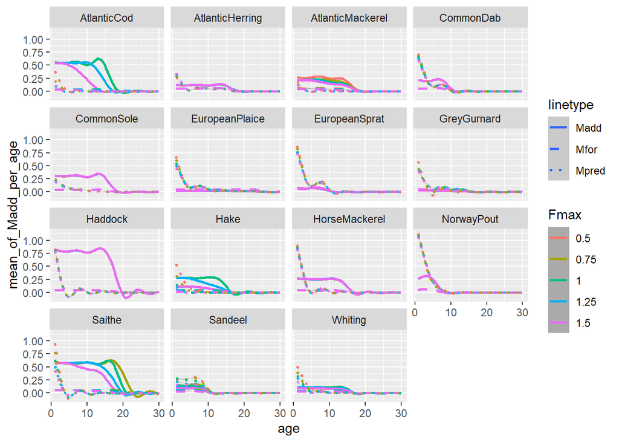

```r
# check Madd > Mfor
data_complete_cw <- pivot_wider(data_complete_c, values_from = "value", names_from="variable")
data_complete_cw$Fmax <- as.factor(data_complete_cw$Fmax)
data_complete_cw$Species <- as.factor(data_complete_cw$Species)
data_complete_cw$mean_of_Madd_per_age <- as.numeric(data_complete_cw$mean_of_Madd_per_age)
data_complete_cw$mean_of_Mfor_per_age <- as.numeric(data_complete_cw$mean_of_Mfor_per_age)
ggplot(data_complete_cw, aes(col = Fmax)) +
  geom_smooth(aes(x = age, y = mean_of_Madd_per_age, linetype = "Madd")) +
  geom_smooth(aes(x = age, y = mean_of_Mfor_per_age, linetype = "Mfor")) +
  geom_smooth(aes(x = age, y = mean_of_Mpred_per_age, linetype = "Mpred")) +
  scale_linetype_manual(values = c("Madd" = 1, "Mfor" = 2, "Mpred" = 3)) +
  facet_wrap(~Species)
```

```r
#combine Mpred, Madd, Mfor and Mstarv into Mnat
df_M <- data_complete_c[data_complete_c$variable %in%
                              c("mean_of_Madd_per_age",
                                "mean_of_Mfor_per_age",
                                "mean_of_Mpred_per_age",
                                "mean_of_Mstar_per_age"), ]
df_M <- df_M %>%  #Mnat
  group_by(Species, age, replicate, Fmax, Fstart) %>%
  summarize(Mnat = sum(value))
```

[output not shown]

```r
df_M <- df_M %>%  #Mnat cumulated between ages
  group_by(Species, replicate, Fmax, Fstart) %>%
  summarize(Mnat = sum(Mnat))
```

[output not shown]

```r
df_M <- df_M %>%  #Mnat cumulated between ages averaged between Fmax, Fstart and replicate
  group_by(Species) %>%
  summarize(Mnat = mean(Mnat))
```

4- Prepare dataset of the selectivity curve

```r
path_csv <- "C:/Users/mbeneat/Documents/osmose/Chap2/osmose-ns/osmose-ns-v4.4.1_clim/fishing_rate"
df_select <- as.data.frame(matrix(-99, ncol=2, nrow=length(list.files(path_csv, pattern = "csv", full.names = T))))
colnames(df_select) <- c("selectq90", "spi")
k=0
for (csv in list.files(path_csv, pattern = "csv", full.names = T)){
  k=k+1
  f <- read.csv(csv)
  f_1 <- f[1, -1]
  f_1 <- f_1[-which(f_1 == 0)]
  q90 <- as.numeric(quantile(as.numeric(f_1), probs = 0.9))
  df_select$selectq90[k] = as.numeric(f_1[which(as.numeric(f_1)>=(q90))[1]])
  df_select$spi[k] <- stringr::str_remove(unlist(stringr::str_split(csv, pattern = "file."))[2], pattern = ".csv")
}
```

5- Combine datasets to shape a unique dataset : df_select + df_Topt + df_param + df_M

```r
df_t <- full_join(df_param, df_select)
df_t <- full_join(df_t, df_Topt, by="Species")
df_t <- full_join(df_t, df_M, by="Species")
df_t <- na.omit(df_t)
rownames(df_t) <- df_t$Species
df_t <- df_t[, -which(colnames(df_t) %in% c("Spe_scien", "Species", "spi"))]
df <- sapply(1:ncol(df_t), function(x) as.numeric(df_t[,x]))
colnames(df) <- colnames(df_t)
rownames(df) <- rownames(df_t)
df <- as.data.frame(df)
```

6- Add species categories (qualitative)

```r
df$"Ne/N_1" <- ifelse(rownames(df) %in%
                        c("Hake", "Whiting", "Saithe", "Sandeel", "AtlanticHerring"), "increasing",
                      ifelse(rownames(df) %in%
                               c("CommonDab", "GreyGurnard", "EuropeanPlaice"), "decreasing",
                             ifelse(rownames(df) %in%
                                      c("AtlanticMackerel"), "constantVkincreasing",
                                    ifelse(rownames(df) %in%
                                             c("NorwayPout", "EuropeanSprat", "AtlanticCod", "CommonSole"), "constantVkdecreasing", "constant"))))
df$"Ne/N_2" <- ifelse(rownames(df) %in% c("Hake", "Whiting", "Saithe", "Sandeel", "AtlanticHerring"), "increasing",
                      ifelse(rownames(df) %in% c("CommonDab", "GreyGurnard", "EuropeanPlaice"), "decreasing",
                             ifelse(rownames(df) %in% c("NorwayPout", "CommonSole", "AtlanticCod", "EuropeanSprat", "Haddock", "HorseMackerel",
                                                        "AtlanticMackerel"), "constant", "out")))
```

7- FINAL DATASET

```r
head(df)
```

```
##                  ratio.max ratio.min       m0         m1 lifespan  egg.weight
## AtlanticHerring        5.0       250 25.35853 -0.8965258       17 0.000667459
## AtlanticMackerel       2.5       150 25.76385  0.7823159       17 0.000585947
## Sandeel                8.0      1000 15.00000  0.0000000       10 0.000997299
## EuropeanSprat          8.0      1000 12.95650  0.0000000       10 0.000280466
## NorwayPout             1.5       500 19.21511 -3.5442479        7 0.000157231
## EuropeanPlaice         5.0        50 43.51328 -4.9883931       25 0.002038534
##                  maturity.r predation.ingestion maint.energy.c_m
## AtlanticHerring   0.7735849           14.016177     1.490000e+11
## AtlanticMackerel  0.7470827           16.443057     5.034833e+06
## Sandeel           1.1987533            9.481859     5.403885e+08
## EuropeanSprat     0.5589685           12.119811     2.565790e+05
## NorwayPout        0.5029810            9.919812     5.816282e+03
## EuropeanPlaice    0.5198261           10.923687     1.536876e+07
##                  mortality.additional.larva.rate  selectq90 Final_Topt     Mnat
## AtlanticHerring                        146.48388 0.01492079  10.260591 4.959614
## AtlanticMackerel                       111.53854 0.10249314  10.710591 4.246238
## Sandeel                                 54.18538 0.07357339  12.460214 3.948656
## EuropeanSprat                           22.47676 0.01386182  12.061138 5.253700
## NorwayPout                              90.27160 0.02347589   7.711138 5.263062
## EuropeanPlaice                         125.18877 0.00558239  12.607324 4.220555
##                                Ne/N_1     Ne/N_2
## AtlanticHerring            increasing increasing
## AtlanticMackerel constantVkincreasing   constant
## Sandeel                    increasing increasing
## EuropeanSprat    constantVkdecreasing   constant
## NorwayPout       constantVkdecreasing   constant
## EuropeanPlaice             decreasing decreasing
```

Split the data into training (80%) and test set (20%) => for LDA

```r
training.samples <- df$"Ne/N_1" %>%
  createDataPartition(p = 0.8, list = FALSE)
train.data <- df[training.samples, ]
test.data <- df[-training.samples, ] #Normalize the data
preproc.param <- train.data %>%
preProcess(method = c("center", "scale")) #Transform the data using the estimated parameters
train.transformed <- preproc.param %>%
  predict(train.data)
train.transformed <- df %>%
  preProcess(method = c("center", "scale")) %>%
  predict(df)
test.transformed <- preproc.param %>%
  predict(test.data)
```

## ANALYSIS

### Linear discriminant analysis - LDA

The LDA algorithm starts by finding directions that maximize the separation between classes, then use these directions to predict the class of individuals. These directions, called linear discriminants, are a linear combinations of predictor variables. LDA assumes that predictors are normally distributed (Gaussian distribution) and that the different classes have class-specific means and equal variance/covariance. Before performing LDA, consider: - Inspecting the univariate distributions of each variable and make sure that they are normally distribute. - If not, you can transform them using log and root for exponential distributions and Box-Cox for skewed distributions. - removing outliers from your data and standardize the variables to make their scale comparable. The linear discriminant analysis can be easily computed using the function lda() [MASS package].

1- Density diagram

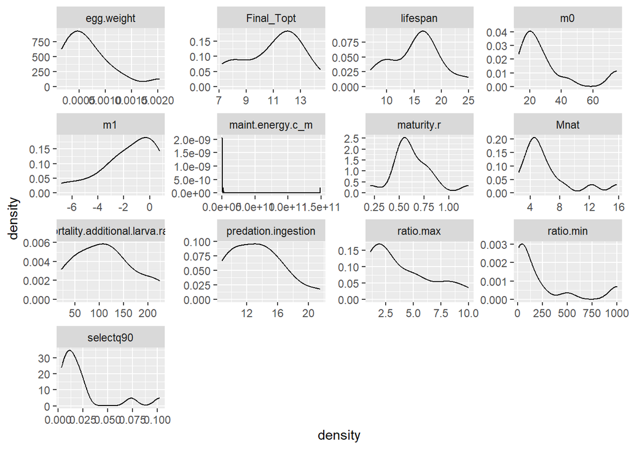

```r
ggplotdata <- train.data[which(sapply(train.data, is.numeric))]
ggplotdata$id <- 1:nrow(ggplotdata)
ggplotdata <- pivot_longer(ggplotdata, cols=-c("id"), values_to = "density", names_to = "variable")
ggplot(ggplotdata)+
  geom_density(aes(density))+
  facet_wrap(~variable, scales="free")
```

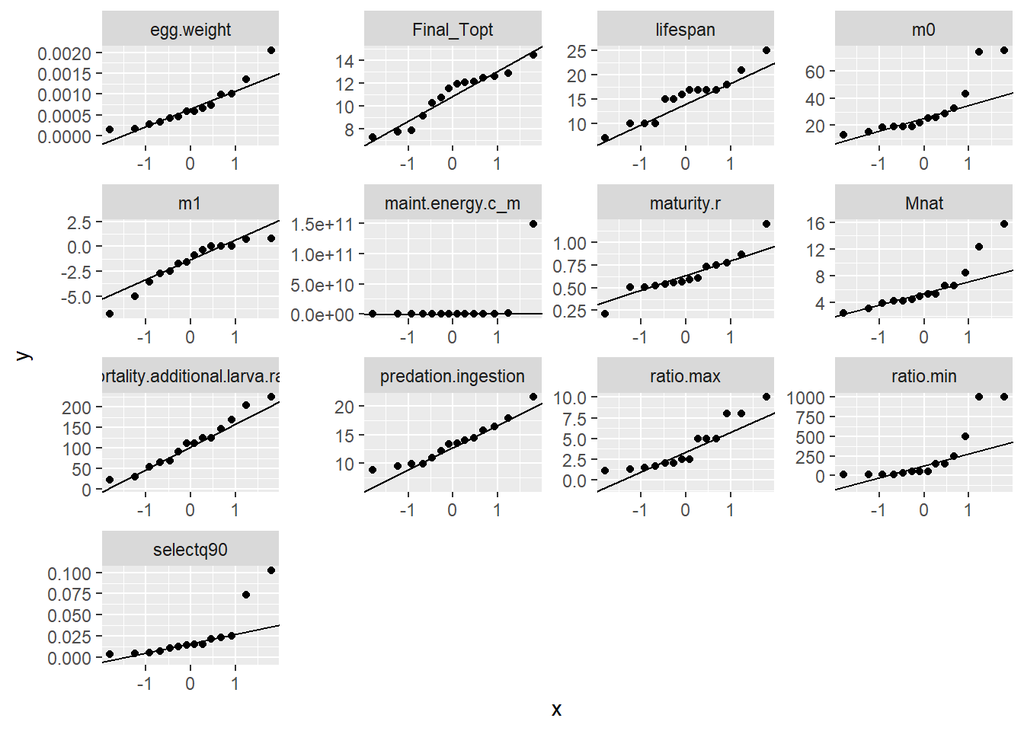

```r
ggplot(ggplotdata, aes(sample=density))+
  stat_qq()+
  stat_qq_line()+
  facet_wrap(~variable, scales="free")
```

2- Transformations applied : I have decided to transform a few variable to have normal distributions instead of Poisson distributions : - c_m - ratio.min - ratio.max - selectivity

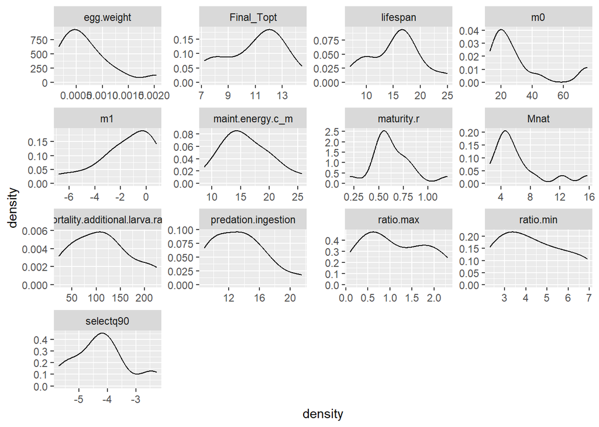

```r
train.data$maint.energy.c_m <- log(train.data$maint.energy.c_m)
train.data$ratio.max <- log(train.data$ratio.max)
train.data$ratio.min <- log(train.data$ratio.min)
train.data$selectq90 <- log(train.data$selectq90)


ggplotdata <- train.data[which(sapply(train.data, is.numeric))]
ggplotdata$id <- 1:nrow(ggplotdata)
ggplotdata <- pivot_longer(ggplotdata, cols=-c("id"), values_to = "density", names_to = "variable")
ggplot(ggplotdata)+
  geom_density(aes(density))+
  facet_wrap(~variable, scales="free")
```

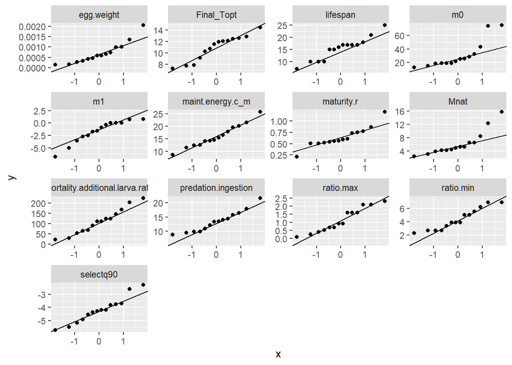

```r
ggplot(ggplotdata, aes(sample=density))+
  stat_qq()+
  stat_qq_line()+
  facet_wrap(~variable, scales="free")
```

```r
model1 <- lda(`Ne/N_1` ~., data = train.transformed[, -which(colnames(train.transformed) == "Ne/N_2")])
predictions <- model1 %>% predict(test.transformed[, -which(colnames(train.transformed) == "Ne/N_2")])
head(predictions$class, 6)
```

```
## [1] increasing
## 5 Levels: constant constantVkdecreasing constantVkincreasing ... increasing
```

```r
head(predictions$posterior, 6)
```

```
##         constant constantVkdecreasing constantVkincreasing   decreasing
## Hake 2.15968e-25           0.01832899         3.034592e-07 2.145477e-20
##      increasing
## Hake  0.9816707
```

```r
head(predictions$x, 3)
```

```
##           LD1        LD2       LD3      LD4
## Hake 3.175787 -0.6341086 -1.329124 1.360926
```

```r
names(predictions)
```

```
## [1] "class"     "posterior" "x"
```

4- Plot model

```r
lda.data <- cbind(train.transformed, predict(model1)$x)
# ggplot(lda.data, aes(LD1, LD2, label=rownames(lda.data))) +
#   geom_point(aes(color = `Ne/N_1`), size=2)+
#   geom_text(hjust=0, vjust=0) #Model accuracy
mean(predictions$class==test.transformed$`Ne/N_1`) #0 = bad, 1=Good
```

```
## [1] 1
```

```r
axis_expl <- model1$scaling #a matrix which transforms observations to discriminant functions, normalized so that within groups covariance matrix is spherical.
pi1 <- ggplot(lda.data, aes(`LD1`, `LD2`)) +
  geom_jitter(aes(color = `Ne/N_1`), size=2)+
  geom_text_repel(hjust=0, vjust=0, max.overlaps = 15, aes(label=rownames(lda.data)))+
  geom_segment(data=axis_expl, aes(x = 0, y = 0, xend = (LD1/0.5), yend = (LD2/0.5)), arrow = arrow(length = unit(1/2, "picas")), color="grey51") +
  geom_text_repel(data=axis_expl, aes(x = (LD1/0.5), y = (LD2/0.5), label=rownames(axis_expl)), color="grey51", max.overlaps = 100)+
  labs(title="LDA analysis explaining the species' Ne/N variation with their traits")
ggsave(pi1, file=paste0(here::here(), "/output/PLOTS/LDA1.pdf"))
```

```r
model2 <- lda(`Ne/N_2`~., data = train.transformed[, -which(colnames(train.transformed) == "Ne/N_1")])
predictions <- model2 %>% predict(test.transformed[, -which(colnames(train.transformed) == "Ne/N_2")])
head(predictions$class, 6)
```

```
## [1] increasing
## Levels: constant decreasing increasing
```

```r
head(predictions$posterior, 6)
```

```
##        constant   decreasing increasing
## Hake 0.03196706 1.783628e-21  0.9680329
```

```r
head(predictions$x, 3)
```

```
##           LD1        LD2
## Hake 2.944754 -0.3128243
```

```r
names(predictions)
```

```
## [1] "class"     "posterior" "x"
```

4b- Plot model

```r
lda.data <- cbind(train.transformed, predict(model2)$x)
# ggplot(lda.data, aes(LD1, LD2, label=rownames(lda.data))) +
#   geom_point(aes(color = `Ne/N_2`), size=2)+
#   geom_text(hjust=0, vjust=0) #Model accuracy
mean(predictions$class==test.transformed$`Ne/N_2`) #0 = bad, 1=Good
```

```
## [1] 1
```

```r
axis_expl <- model2$scaling #a matrix which transforms observations to discriminant functions, normalized so that within groups covariance matrix is spherical.
pi2 <- ggplot(lda.data, aes(`LD1`, `LD2`)) +
  geom_jitter(aes(color = `Ne/N_2`), size=2)+
  geom_text_repel(hjust=0, vjust=0, max.overlaps = 15, aes(label=rownames(lda.data)))+
  geom_segment(data=axis_expl, aes(x = 0, y = 0, xend = (LD1/0.5), yend = (LD2/0.5)), arrow = arrow(length = unit(1/2, "picas")), color="grey51") +
  geom_text_repel(data=axis_expl, aes(x = (LD1/0.5), y = (LD2/0.5), label=rownames(axis_expl)), color="grey51", max.overlaps = 100)+
  labs(title="LDA analysis explaining the species' Ne/N variation with their traits")
ggsave(pi2, file=paste0(here::here(), "/output/PLOTS/LDA2.pdf"))
```

5- PLOTS

FIGURE : LDA with 5 categories of responses of Ne/N to ↑ Fishing mortality rate:

Here we have 5 categories of Ne/N. The discriminant analysis worked well and all five categories are well differentiated. We expected the ‘decreasing’ (blue) and ‘constantVkincreasing’ (green) categories to be related, as well as the ‘increasing’ (pink) and ‘constantVkdecreasing’ (yellow). The ‘constant’ category is separated, and that was also expected.

We can relate the resilience level of the species to exploitation, to the pace of life syndrome theory : species with the fastest pace of life are the least affected by fishing mortality (red) : they are characterized by short lifespan and large egg weight. Species with the slowest pace of life (yellow, pink) (late maturation, longer lifespan, lowest optimal temperature) are the ones the most resilient to exploitation : increasing Ne/N. Lastly, the species the least resilient to exploitation are the ones with intermediate (blue, green) life-history strategies.

Weird :

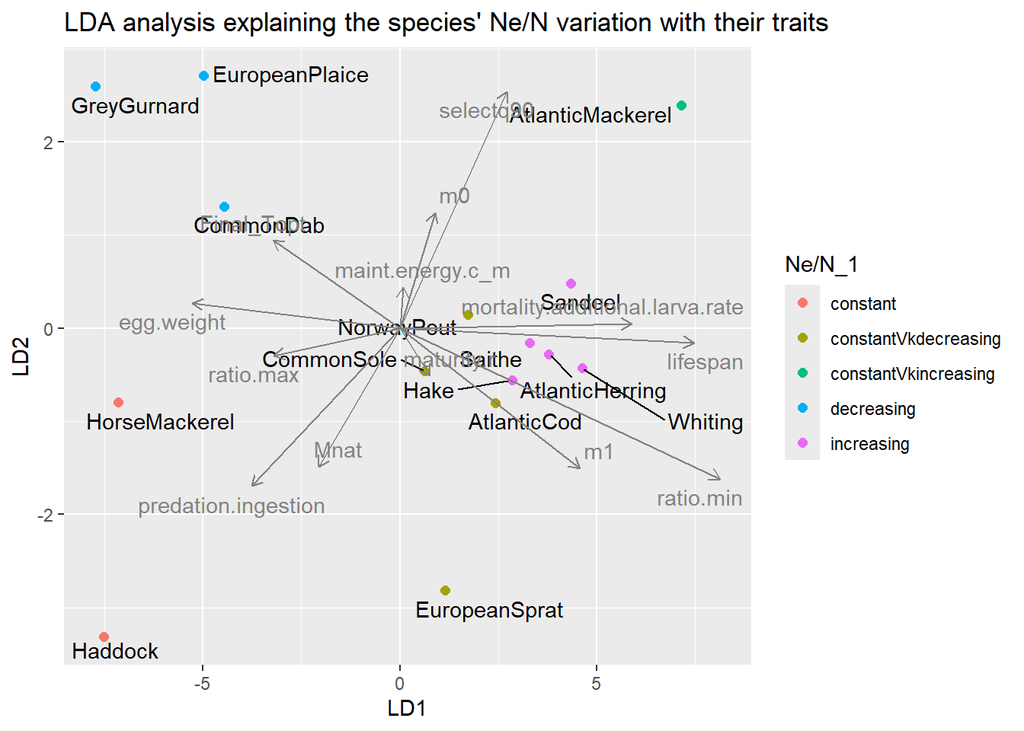

```r
pi1
```

I found useful to have the projected coordinates of the individuals in the variables space.

```r
Z <- predict(model1)$x
# Coefficients des variables
A <- model1$scaling
# Reconstruction approximative
Xhat <- Z %*% t(A)
Xhat
```

```
##                   ratio.max  ratio.min         m0         m1   lifespan
## AtlanticHerring   -6.820810  17.148327  1.4101641   9.361677  15.399242
## AtlanticMackerel -10.147304  23.042398  6.6085736  15.206505  20.471530
## Sandeel           -6.061130  14.936667  3.2227621   9.808707  12.890087
## EuropeanSprat     -2.246387   9.188945 -2.4899478   4.183515   8.153873
## NorwayPout        -3.476574   8.832358 -0.4217280   3.113368   9.817179
## EuropeanPlaice     6.980306 -21.277584 -0.8696422 -13.384595 -17.541207
## CommonSole        -1.400897   4.284847 -0.8544892   1.346913   4.745201
## Saithe            -5.557446  14.447927  0.8742838   7.465993  13.855556
## AtlanticCod       -3.649531  10.232953  0.8539704   6.372126   8.570300
## Haddock           13.702310 -30.953113 -3.8972040 -14.185543 -32.499997
## HorseMackerel     12.228831 -30.167620 -2.8833019 -15.543619 -29.231551
## Whiting           -8.319150  21.784292  0.2985631  10.216937  21.584678
## CommonDab          6.993269 -19.142207 -1.5059396 -11.559985 -16.236232
## GreyGurnard       11.583284 -32.402983 -2.5055939 -19.984061 -27.152684
## Hake              -3.808770  10.044792  2.1595294   7.582064   7.174025
##                  egg.weight  maturity.r predation.ingestion maint.energy.c_m
## AtlanticHerring   -9.342283  0.92089279           -7.373292      1.489719053
## AtlanticMackerel -14.727739  0.91465679          -13.514809      1.534273518
## Sandeel           -9.451476  0.97488577           -7.483911      0.504577814
## EuropeanSprat     -6.197436  2.18903416           -0.942175     -1.558426518
## NorwayPout        -7.240655  1.67374410           -4.419274     -0.980534720
## EuropeanPlaice    13.511809 -2.80799852            6.648741      1.098616697
## CommonSole        -3.771792  1.16180791           -1.541454     -0.965979518
## Saithe           -10.089964  1.83464719           -6.581707     -0.508815724
## AtlanticCod       -6.138947  0.98921050           -3.741649      0.039489557
## Haddock           22.633808 -3.14442337           18.511868     -0.130183631
## HorseMackerel     20.517715 -3.12904656           15.005437      0.002006816
## Whiting          -15.431762  3.04486602           -9.709046     -0.986369624
## CommonDab         11.048271 -1.60238005            7.167263     -0.559013538
## GreyGurnard       19.059035 -2.99294468           11.731232     -0.421122294
## Hake              -4.378585 -0.02695205           -3.757224      1.441762113
##                  mortality.additional.larva.rate   selectq90 Final_Topt
## AtlanticHerring                        11.861559   3.4548498  -6.718966
## AtlanticMackerel                       19.334507  16.2507578  -8.863533
## Sandeel                                11.752662   8.3965497  -5.904899
## EuropeanSprat                           4.267305  -3.8830163  -4.040998
## NorwayPout                              5.838628   0.6632264  -3.462721
## EuropeanPlaice                        -14.113561  -4.5846417   8.913542
## CommonSole                              2.416707  -0.8107064  -1.769836
```

[output cut: 9 more lines]

```
## AtlanticHerring  -4.8724230
## AtlanticMackerel -7.5913678
## Sandeel          -3.8968821
## EuropeanSprat     0.2688326
## NorwayPout       -2.4084776
## EuropeanPlaice    2.3100767
## CommonSole       -0.5801668
## Saithe           -3.4408259
## AtlanticCod      -1.7810468
## Haddock          11.2589293
## HorseMackerel     8.5583224
## Whiting          -5.2613247
## CommonDab         3.8238478
## GreyGurnard       5.8017908
## Hake             -2.1892849
```

FIGURE : LDA with 3 categories of responses of Ne/N to ↑ Fishing mortality rate:

Here we have 3 categories of Ne/N. The discriminant analysis worked well and all three categories are well differentiated.

Weird : - inconsistent with first lda plot, I believe it is due to the subcategories that bring nuance that is not included here. I trust more the 5 categories LDA than the 3 categories LDA.

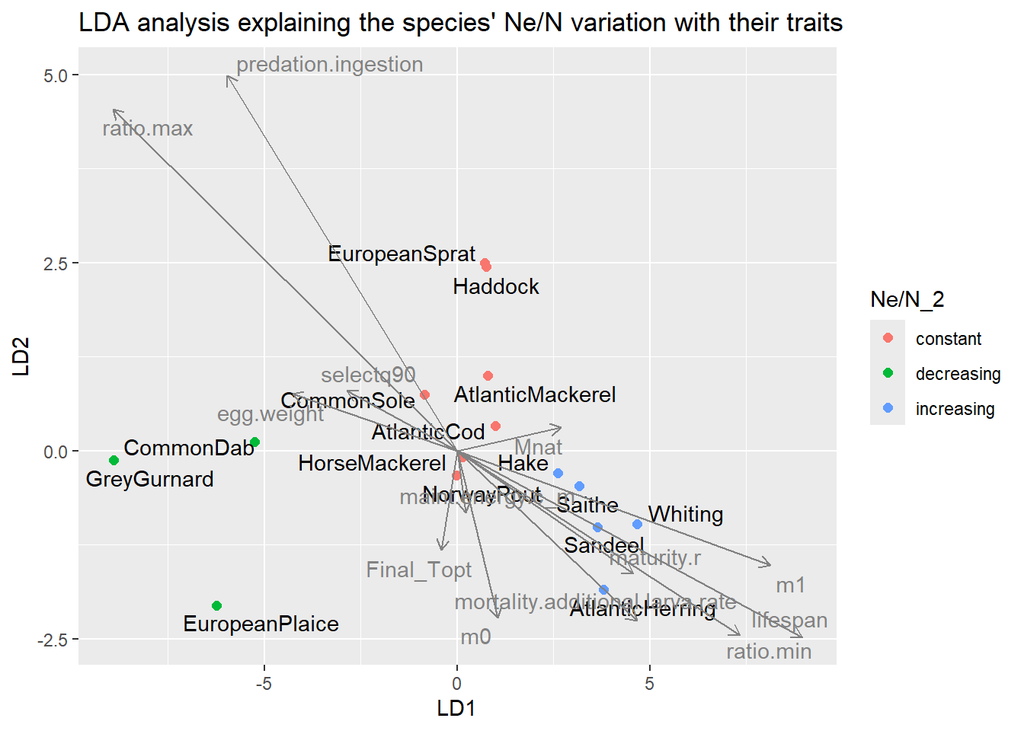

```r
pi2
```

I found useful to have the projected coordinates of the individuals in the variables space.

```r
Z <- predict(model2)$x
# Coefficients des variables
A <- model2$scaling
# Reconstruction approximative
Xhat <- Z %*% t(A)
Xhat
```

```
##                    ratio.max   ratio.min         m0          m1    lifespan
## AtlanticHerring  -21.1130772  19.2305934  4.0452246  16.7877153  16.1672931
## AtlanticMackerel  -1.3277204   2.3770032 -0.6900370   2.5222525   1.7370599
## Sandeel          -18.5101658  17.4982033  3.0301312  15.5199073  14.5679888
## EuropeanSprat      2.4769334   0.1105290 -2.3887300   1.0028738  -0.4366847
## NorwayPout        -0.6670881   0.3310555  0.3514937   0.1830845   0.3402086
## EuropeanPlaice    23.2704225 -25.4323560 -1.0318020 -23.8242961 -20.4330421
## CommonSole         5.4656588  -4.7073876 -1.2663519  -4.0056366  -4.0181655
## Saithe           -15.2103154  14.7493164  2.1902291  13.2185431  12.1995261
## AtlanticCod       -3.6405266   3.9990323  0.1450142   3.7526520   3.2091477
## Haddock            2.2225105   0.3171669 -2.3196817   1.1736493  -0.2573458
## HorseMackerel     -0.7899687   0.7018637  0.1656481   0.6059381   0.5940159
## Whiting          -23.0368833  22.0790347  3.5272264  19.6941352  18.3166946
## CommonDab         23.7191899 -23.6430198 -2.8956348 -21.4204179 -19.4206293
## GreyGurnard       39.5699326 -39.7528513 -4.5799656 -36.1243031 -32.5900283
## Hake             -12.4289025  12.1418162  1.7172357  10.9139027  10.0239612
##                    egg.weight  maturity.r predation.ingestion maint.energy.c_m
## AtlanticHerring   -8.78209704  10.1674969        -15.91734700       1.17585023
## AtlanticMackerel  -1.34793758   1.0306717          0.09563213      -0.32507037
## Sandeel           -8.13444553   9.1279411        -13.35539604       0.81271811
## EuropeanSprat     -0.58235429  -0.3997886          4.08998989      -0.94666842
## NorwayPout        -0.08903086   0.2285806         -0.76264939       0.13165617
## EuropeanPlaice    12.56645808 -12.6261308         13.56482545       0.15179213
## CommonSole         2.08884563  -2.5413251          4.37506698      -0.39698537
## Saithe            -6.93680342   7.6248535        -10.62648821       0.54120548
## AtlanticCod       -1.97977301   1.9820839         -2.10309152      -0.03067825
## Haddock           -0.67107921  -0.2856761          3.87460528      -0.92392161
## HorseMackerel     -0.31655121   0.3745069         -0.61215936       0.05003384
## Whiting          -10.32925883  11.4612686        -16.33825819       0.90841047
## CommonDab         11.25531190 -12.1056797         15.96749297      -0.62433371
## GreyGurnard       18.98809356 -20.2993770         26.34690756      -0.93562491
## Hake              -5.72937819   6.2605741         -8.59913057       0.41161618
##                  mortality.additional.larva.rate   selectq90  Final_Topt
## AtlanticHerring                       10.9210025 -6.14128550  0.42918545
## AtlanticMackerel                       0.7504087 -0.75414174 -0.83261848
## Sandeel                                9.6094042 -5.58533861 -0.09373173
## EuropeanSprat                         -1.1522624 -0.02525737 -1.79259829
## NorwayPout                             0.3299896 -0.10689575  0.21715300
## EuropeanPlaice                       -12.2677879  8.10384299  2.64597384
## CommonSole                            -2.8124159  1.50445256 -0.31056711
```

[output cut: 9 more lines]

```
## AtlanticHerring    4.81607448
## AtlanticMackerel   1.24857158
## Sandeel            4.73940933
## EuropeanSprat      1.35174196
## NorwayPout        -0.07181588
## EuropeanPlaice    -8.73959931
## CommonSole        -1.02732410
## Saithe             4.19462407
## AtlanticCod        1.38368884
## Haddock            1.38944907
## HorseMackerel      0.16588766
## Whiting            6.14271003
## CommonDab         -7.06170468
## GreyGurnard      -12.03187164
## Hake               3.50015860
```

### PCA : non supervised analysis

1- PCA

```r
res.pca <- prcomp(df[, -c(ncol(df), ncol(df)-1)], scale = F)
```

2- PLOTS

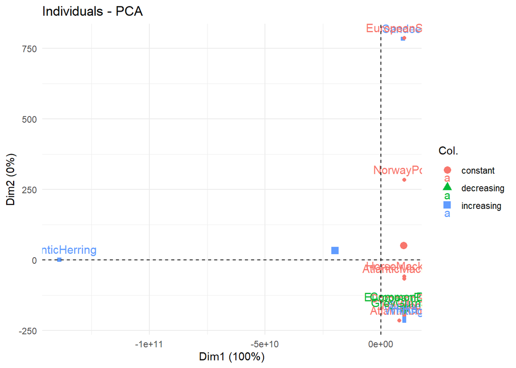

```r
fviz_pca_ind(res.pca, col.ind = df$`Ne/N_2`)+
  theme_minimal()
```

The PCA to differentiate the 3 groups of responses of Ne/N to increasing exploitation is not satisfactory when using PCA1 and PCA2.

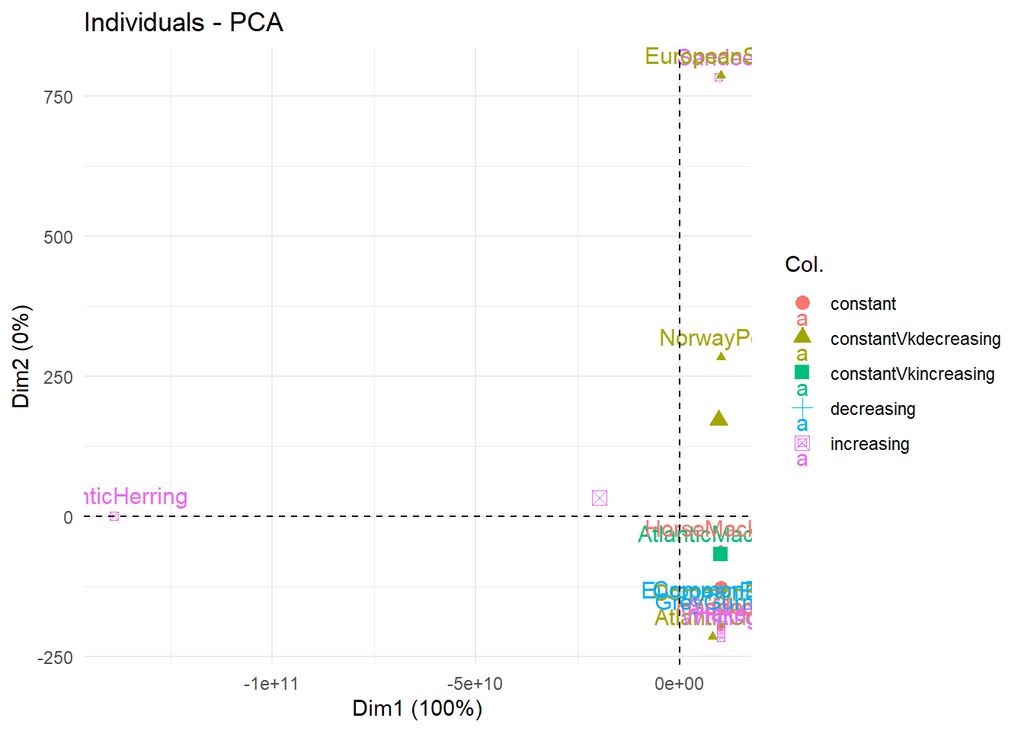

```r
fviz_pca_ind(res.pca, col.ind = df$`Ne/N_1`)+
  theme_minimal()
```

The PCA to differentiate the 5 groups of responses of Ne/N to increasing exploitation is not satisfactory when using PCA1 and PCA2.

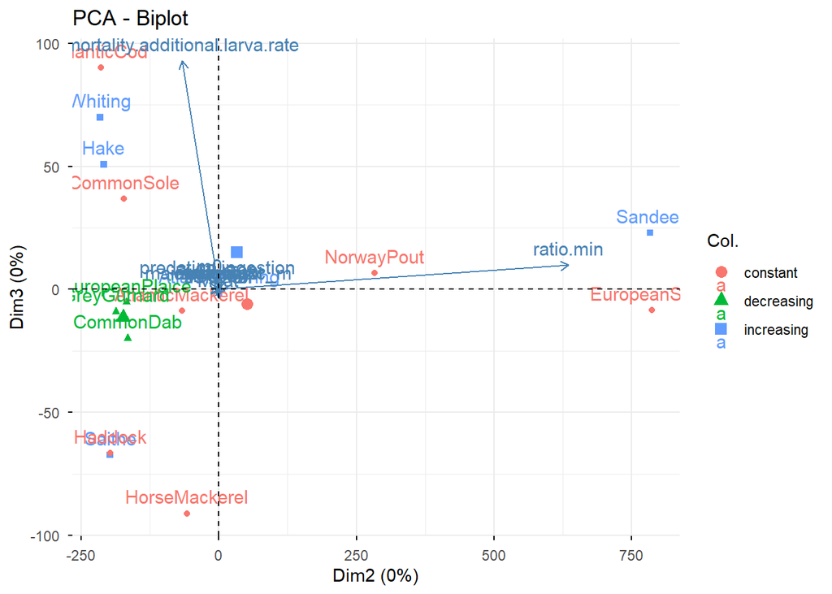

```r
fviz_pca_biplot(res.pca, axes = c(2,3), col.ind = df$`Ne/N_2`)
```

The PCA, using PCA2 and PCA3, to differentiate the 3 groups of responses of Ne/N to increasing exploitation isolates the ‘decreasing’ category. These species are chatecterised by low ratio.min and average larval mortality. The other traits do not participate to explain the categories of Ne/N. Plus, the percentage of variance explained is null.

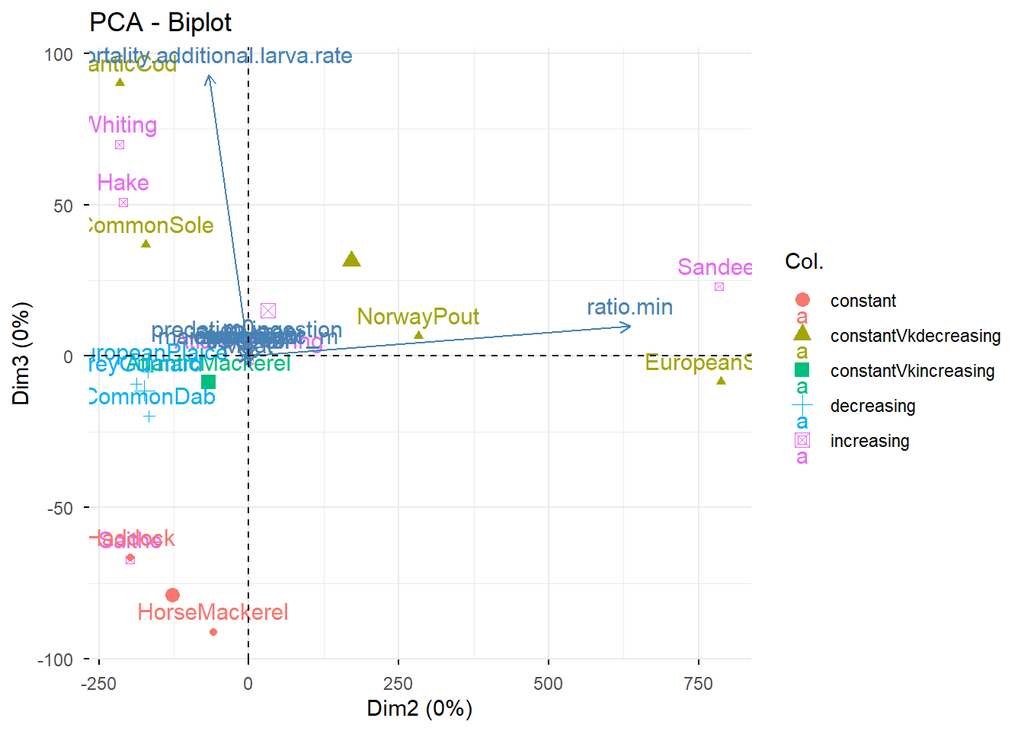

```r
fviz_pca_biplot(res.pca, axes = c(2,3), col.ind = df$`Ne/N_1`)
```

The PCA, using PCA2 and PCA3, to differentiate the 5 groups of responses of Ne/N to increasing exploitation isolates the ‘decreasing’, ‘constantVkincreasing’ and ‘constant’ categories. ‘decreasing’ and ‘constantVkincreasing’ species are characterised by low ratio.min and average larval mortality. The ‘constant’ category species are chatacterised by low ratio.min and larval mortality. Plus, the percentage of variance explained is null.

Values of the projected species in the variables space (PCA1, PCA2)

```r
Z <- res.pca$x
A <- res.pca$rotation
# Reconstruction approximative
Xhat <- Z[, c(1:2)] %*% t(A)[c(1:2), ]
Xhat
```

```
##                   ratio.max  ratio.min         m0         m1   lifespan
## AtlanticHerring   1.2093808   30.14833  -5.164619  0.5726605  1.6593960
## AtlanticMackerel -0.3891325  -68.93463   2.147321 -0.1378566  0.4406694
## Sandeel           3.4319589  777.50036 -20.327977  1.0830182 -6.6758388
## EuropeanSprat     3.4426986  780.80783 -20.398758  1.0857223 -6.7111168
## NorwayPout        1.1818667  279.45361  -7.096311  0.3637902 -2.4915532
## EuropeanPlaice   -0.8433724 -169.68308   4.820157 -0.2828911  1.2887449
## CommonSole       -0.8599259 -173.41811   4.918082 -0.2881268  1.3206960
## Saithe           -0.9752982 -198.91265   5.596180 -0.3250381  1.5345429
## AtlanticCod      -1.0333103 -215.31947   5.966552 -0.3407877  1.7010974
## Haddock          -0.9713974 -198.05051   5.573252 -0.3237903  1.5273101
## HorseMackerel    -0.3496035  -60.16034   1.914668 -0.1252407  0.3667542
## Whiting          -1.0565181 -216.92555   6.074082 -0.3509719  1.6861605
## CommonDab        -0.8311941 -167.44651   4.752305 -0.2786388  1.2736506
## GreyGurnard      -0.9299210 -188.85199   5.329203 -0.3105466  1.4498856
## Hake             -1.0262316 -210.20730   5.895864 -0.3413024  1.6296012
##                     egg.weight  maturity.r predation.ingestion maint.energy.c_m
## AtlanticHerring  -3.291064e-05  0.16292530           0.3950339     138868529918
## AtlanticMackerel  1.687766e-05 -0.03260795           0.2839083     -10126435249
## Sandeel          -1.668500e-04  0.23087421          -3.6802768      -9591081564
## EuropeanSprat    -1.674650e-04  0.23130418          -3.6978611     -10131213503
## NorwayPout       -5.870090e-05  0.07559071          -1.3486001     -10131464265
## EuropeanPlaice    3.873211e-05 -0.06388750           0.7560386     -10116101326
## CommonSole        3.953528e-05 -0.06500614           0.7736849     -10078660121
## Saithe            4.507605e-05 -0.07298246           0.8929452     -10131195612
## AtlanticCod       4.824295e-05 -0.07579304           0.9778055      -8064709433
## Haddock           4.488870e-05 -0.07271283           0.8889118     -10129508634
## HorseMackerel     1.497509e-05 -0.02988824           0.2427744     -10131366404
## Whiting           4.898358e-05 -0.07857580           0.9773548     -10130112083
## CommonDab         3.819550e-05 -0.06289350           0.7466038      -9845390610
## GreyGurnard       4.289326e-05 -0.06985644           0.8458072     -10129995276
## Hake              4.752634e-05 -0.07649052           0.9458696     -10131295840
##                  mortality.additional.larva.rate     selectq90   Final_Topt
## AtlanticHerring                        32.401044 -0.0084690965 -0.706903587
## AtlanticMackerel                        4.629826 -0.0011893769 -0.009104622
## Sandeel                               -83.921614  0.0216929419  0.757341644
## EuropeanSprat                         -84.406478  0.0218186109  0.763203708
## NorwayPout                            -31.875198  0.0082439363  0.307552416
## EuropeanPlaice                         15.188785 -0.0039179379 -0.100723862
## CommonSole                             15.589725 -0.0040215713 -0.104316401
```

[output cut: 9 more lines]

```
## AtlanticHerring  -1.1438679
## AtlanticMackerel  0.2415021
## Sandeel          -1.7677365
## EuropeanSprat    -1.7714002
## NorwayPout       -0.5837495
## EuropeanPlaice    0.4800835
## CommonSole        0.4886422
## Saithe            0.5494414
## AtlanticCod       0.5723482
## Haddock           0.5473861
## HorseMackerel     0.2207550
## Whiting           0.5921035
## CommonDab         0.4726947
## GreyGurnard       0.5255997
## Hake              0.5761979
```

Values of the projected species in the variables space (PCA2, PCA3)

```r
Xhat <- Z[, c(2:3)] %*% t(A)[c(2:3), ]
Xhat
```

```
##                     ratio.max    ratio.min           m0           m1
## AtlanticHerring  -0.001199819    0.4018894  -0.05599024 -0.005256783
## AtlanticMackerel -0.325065694  -67.6795788   1.49676200 -0.135947574
## Sandeel           3.579103752  781.9537100 -19.95115819  1.228518238
## EuropeanSprat     3.507367772  782.0850703 -21.04305396  1.088582951
## NorwayPout        1.288315214  282.3082800  -7.26083714  0.436079288
## EuropeanPlaice   -0.769951549 -168.0736667   4.27843598 -0.265330481
## CommonSole       -0.669900539 -167.4017658   5.72060016 -0.076400296
## Saithe           -1.074137449 -203.8089786   3.07411759 -0.593903685
## AtlanticCod      -0.712903245 -204.1488305   8.54211655  0.108408717
## Haddock          -1.067909951 -202.8587937   3.07814029 -0.588771807
## HorseMackerel    -0.514295947  -67.5431080  -1.36369189 -0.503546259
## Whiting          -0.774324309 -207.4351224   7.92804061  0.013393326
## CommonDab        -0.800784522 -167.4299477   3.75369373 -0.329761173
## GreyGurnard      -0.867059793 -187.6428742   4.66430976 -0.310677995
## Hake             -0.797253923 -202.7262833   7.13851474 -0.065386466
##                      lifespan    egg.weight    maturity.r predation.ingestion
## AtlanticHerring   0.009411596  2.115906e-06 -0.0009902449         -0.03432903
## AtlanticMackerel  0.654005141  2.921428e-05 -0.0283753729          0.10311877
## Sandeel          -6.805989230 -2.083476e-04  0.2624558746         -3.09400353
## EuropeanSprat    -6.499878585 -1.554744e-04  0.2357212010         -3.87372355
## NorwayPout       -2.440824244 -7.240626e-05  0.0933303489         -1.15845957
## EuropeanPlaice    1.465672636  4.526257e-05 -0.0566554902          0.65795521
## CommonSole        1.047918407 -2.584540e-05 -0.0205302374          1.69989615
## Saithe            2.373996222  1.576355e-04 -0.1207065946         -0.71538333
## AtlanticCod       0.835996830 -1.076220e-04  0.0134816940          3.19385020
## Haddock           2.357747524  1.560084e-04 -0.1196923102         -0.69890952
## HorseMackerel     1.459230155  1.680397e-04 -0.0986125902         -1.94249507
## Whiting           1.061597147 -7.282413e-05 -0.0047906221          2.70726621
## CommonDab         1.603548380  6.979761e-05 -0.0689443257          0.29154459
## GreyGurnard       1.668015049  5.598964e-05 -0.0660140317          0.65419431
## Hake              1.209552972 -4.154378e-05 -0.0196772984          2.20947818
##                  maint.energy.c_m mortality.additional.larva.rate     selectq90
## AtlanticHerring      2.292665e-10                       -1.354959 -8.175695e-05
## AtlanticMackerel     1.485112e-08                       -1.568314 -2.443550e-03
## Sandeel             -1.536727e-07                      -58.864376  2.279995e-02
## EuropeanSprat       -1.463621e-07                      -90.402897  2.057903e-02
## NorwayPout          -5.509025e-08                      -22.928279  8.113154e-03
## EuropeanPlaice       3.309710e-08                       12.366195 -4.920830e-03
## CommonSole           2.312979e-08                       54.583047 -1.918725e-03
```

[output cut: 9 more lines]

```
## AtlanticHerring  -0.002059686  0.04045188
## AtlanticMackerel -0.077505340  0.43342970
## Sandeel           0.753281938 -2.57985706
## EuropeanSprat     0.695172526 -1.58595864
## NorwayPout        0.268860279 -0.87853148
## EuropeanPlaice   -0.162439487  0.56354082
## CommonSole       -0.083720829 -0.77168180
## Saithe           -0.310072902  2.61438226
## AtlanticCod      -0.018332062 -2.37132515
## Haddock          -0.307645346  2.58542759
## HorseMackerel    -0.230218830  3.04268340
## Whiting          -0.058836050 -1.72296343
## CommonDab        -0.189013847  1.02574071
## GreyGurnard      -0.187359258  0.73171240
## Hake             -0.090111104 -1.12705118
```

Conclusion : the PCA analysis representation of the variance in Ne/NT categories is not sufficient.

### Ne/NT as quantitative variable (slope with Fmax)

1- Estimate the slope of Ne/N with Fmax

```r
Ne_NT = NULL
for (sp in rownames(df)){ #load and filter data
  load(file=paste0(pathoutputRDATA, "/Complete_INIT2", sp, ".RData"))
  final_dataset_age = complete[[2]]
  rm(complete)
  NeNT <- final_dataset_age[which(final_dataset_age$variable %in% c("Ne_N_alpha", "NT")), -which(colnames(final_dataset_age) %in% c("age", "Fstart"))]
  rm(final_dataset_age)
  if (is.null(Ne_NT)) {Ne_NT <- pivot_wider(NeNT, values_from = "value", names_from = "variable")
  } else Ne_NT <- rbind(Ne_NT, pivot_wider(NeNT, values_from = "value", names_from = "variable"))
}
Ne_NT       <- Ne_NT[-which(Ne_NT$NT < 10), ] # removing the cases of low abundance( = collapses )
Ne_NT$Ne_NT <- Ne_NT$Ne_N_alpha/Ne_NT$NT
Ne_NT       <- Ne_NT[, -which(colnames(Ne_NT) %in% c("Ne_N_alpha", "NT"))]

Ne_NT <- Ne_NT %>%
  group_by(Species, replicate) %>%
  nest() %>%
  mutate(model = map(data, ~lm(Ne_NT ~ 1 + Fmax, data = .x) %>% tidy)) %>%
  unnest(model) %>%
  filter(term == 'Fmax') %>% ungroup()
Ne_NT <- Ne_NT[, c("Species", "estimate", "replicate")]
Ne_NT <- Ne_NT %>%
  group_by(Species) %>%
  summarise(Ne_NT = mean(estimate, na.rm = T)) %>%
  ungroup()
```

2- run the PCA using the slope of Ne/N as the explained variable

```r
pca_var <- as.data.frame(res.pca$x)
pca_var$Species <- rownames(pca_var)

df_Ne_NT <- full_join(pca_var, Ne_NT, by = "Species")
df_Ne_NT <- df_Ne_NT[, -which(colnames(df_Ne_NT) == c("Species"))]

df_sp     <- df
df_sp$Species <- rownames(df)
df_Ne_NT2 <- full_join(df_sp, Ne_NT, by = "Species")
df_Ne_NT2 <- df_Ne_NT2[, -which(colnames(df_Ne_NT2) %in% c("Species", "Ne/N_2", "Ne/N_1"))]

lm(data = df_Ne_NT, formula = Ne_NT ~ PC1 + PC2 + PC3 + PC4 + PC5 + PC6 + PC7 + PC8 + PC9 + PC10 + PC11 + PC12 + PC13)
```

```
##
## Call:
## lm(formula = Ne_NT ~ PC1 + PC2 + PC3 + PC4 + PC5 + PC6 + PC7 +
##     PC8 + PC9 + PC10 + PC11 + PC12 + PC13, data = df_Ne_NT)
##
## Coefficients:
## (Intercept)          PC1          PC2          PC3          PC4          PC5
##   7.402e-02   -8.781e-14   -4.109e-05    1.013e-03    6.329e-03   -1.334e-02
##         PC6          PC7          PC8          PC9         PC10         PC11
##   9.806e-03   -8.851e-03   -3.189e-02    2.855e-02   -2.820e-02   -8.258e-02
##        PC12         PC13
##  -4.691e+00   -1.091e+02
```

```r
fit <- plsr(Ne_NT ~ ., data = df_Ne_NT2, scale = TRUE, validation = "CV")
```

3- RESULTS

What is the estimated effect of each variable on y?

```r
coef(fit, ncomp = 5)
```

```
## , , 5 comps
##
##                                        Ne_NT
## ratio.max                       -0.037180073
## ratio.min                        0.055227217
## m0                               0.168193992
## m1                               0.090123703
## lifespan                        -0.038407040
## egg.weight                      -0.014257550
## maturity.r                       0.019264618
## predation.ingestion             -0.007944058
## maint.energy.c_m                 0.005831629
## mortality.additional.larva.rate  0.040939419
## selectq90                       -0.013844675
## Final_Topt                       0.002662069
## Mnat                            -0.006157543
```

How important was the variable in building the predictive components? Variables with Variable Importance in Projection indec (VIP) > 1 are usually considered important:

```r
VIP(fit, opt.comp = 5)
```

```
##                       ratio.max                       ratio.min
##                       1.0234752                       0.9234054
##                              m0                              m1
##                       1.6729731                       1.1627402
##                        lifespan                      egg.weight
##                       0.7212190                       1.0815007
##                      maturity.r             predation.ingestion
##                       0.8623654                       1.2482515
##                maint.energy.c_m mortality.additional.larva.rate
##                       0.3123542                       0.7104213
##                       selectq90                      Final_Topt
##                       0.6262989                       1.1316676
##                            Mnat
##                       0.8259693
```